# HW4_solution

liyuan

2019/11/10

## Q1: The Gaussian VaR at $\alpha$ quantile of an investment $I$ is $VaR_{\alpha}=−(\sigma Z_{\alpha}+\mu)×I$. Suppose we have two investment, A and B. The returns of A is $r_A \sim N(\mu_A,\sigma^2_A)$ and the returns of B is $r_B\sim N(\mu_B,\sigma^2_B)$. The correlation between $r_A$ and $r_B$ is $\rho_{AB}$. We have a portfolio, constructed by investing $0.5 in A and $0.5 in B.

### (Hint: If you would like to use LaTeX to type the formula, you may refer to ‘HW Template’ or this website: https://www.overleaf.com/learn/latex/List_of_Greek_letters_and_math_symbols)

1. What is the distribution of our portfolio return, denoted by $r_p$?
2. What is $VaR_{\alpha}^p$ of our portfolio?
3. Prove the subadditivity property of VaR holds.

solution:

1. $r_P\sim N(\mu_{A+B},\sigma^2_{A+B})$, where $\sigma^2_{A+B}=0.25\sigma^2_A+0.25\sigma^2_B+2*0.25\rho_{AB}\sigma_A\sigma_B$.
2. $VaR^{A+B}_{\alpha}=-(\sigma_{A+B}*Z_{\alpha}+\mu_{A+B})*I$, where $\sigma_{A+B}=(0.25\sigma^2_A+0.25\sigma^2_B+2*0.25\rho_{AB}\sigma_A\sigma_B)^{1/2}$.
3. $VaR_{\alpha}^{A}+VaR_{\alpha}^{B}= -(\sigma_A Z_{\alpha}+\mu_A)*I-(\sigma_B Z_{\alpha}+\mu_B)*I=-[Z_{\alpha}*(\sigma_A+\sigma_B)+\mu_{AB}]*I$.

As $\rho_{AB}\leq1$, $VaR^{A+B}_{\alpha}\leq VaR_{\alpha}^{A}+VaR_{\alpha}^{B}$.

## Q2: Use SQL quote to obtain daily closing price of CSI 300 index and FTSE 350 index from 2014 to 2018 from compustats database in WRDS.

### (Hint: you may need to check the file ‘G_IDX_INDEX’ (it is a sub dataset in the dataset ‘Compustat - Non-Historical NA - Daily Update (COMPDCUR)’) to get the ‘gvkeyx’ for the two indices first, and then obtain the closing prices from ‘G_IDX_DAILY’.)

1. Suppose the total investment is 1 million dollar. Calculate the historical and Gaussian $VaR_{0.05}$ and the corresponding expeted shortfall for the two indices.

solution:

Step1: obtain data from WRDS

```r
library(RPostgres)
wrds = dbConnect(Postgres(),
                 host='wrds-pgdata.wharton.upenn.edu',
                 port=9737,
                 user='username',
                 password='passwords',
                 dbname='wrds',
                 sslmode='require')



gvkeyx = paste0(c('150036','153435'),collapse = "','")
gvkeyx

# create the sql quote
q = paste0("select gvkeyx,datadate,prccd from COMP.G_IDX_DAILY where gvkeyx in ('",
           gvkeyx,"') and datadate>'2013-12-31'")
q
res = dbSendQuery(wrds, q)
ind.g.price = dbFetch(res, n=-1)
dbClearResult(res)
save(ind.g.price,file='ind.g.price.RData')
```

Step2: Calculate daily rets for the two indices

```r
load('HW4/ind.g.price.RData')
head(ind.g.price)
```

```
##   gvkeyx   datadate   prccd
## 1 150036 2014-01-02 3659.34
## 2 150036 2014-01-03 3668.78
## 3 150036 2014-01-06 3669.82
## 4 150036 2014-01-07 3681.93
## 5 150036 2014-01-08 3664.02
## 6 150036 2014-01-09 3648.12
```

```r
library(dplyr)
library(tidyr)
ind.g.price= ind.g.price %>% filter(datadate<'2019-01-01')
colnames(ind.g.price)=c("gvkeyx","date","price")
summary(ind.g.price)
```

```
##     gvkeyx               date                price
##  Length:2481        Min.   :2014-01-02   Min.   :2087
##  Class :character   1st Qu.:2015-04-02   1st Qu.:3361
##  Mode  :character   Median :2016-07-01   Median :3665
##                     Mean   :2016-06-30   Mean   :3591
##                     3rd Qu.:2017-09-27   3rd Qu.:3950
##                     Max.   :2018-12-31   Max.   :5354
```

```r
index = spread(ind.g.price, gvkeyx, price)
index = index %>% na.omit(153435, 150036)
ind.g.price = gather(index,gvkeyx,price, -date)
summary(ind.g.price)
```

```
##       date               gvkeyx              price
##  Min.   :2014-01-02   Length:2372        Min.   :2087
##  1st Qu.:2015-04-02   Class :character   1st Qu.:3356
##  Median :2016-06-30   Mode  :character   Median :3661
##  Mean   :2016-06-30                      Mean   :3587
##  3rd Qu.:2017-09-22                      3rd Qu.:3944
##  Max.   :2018-12-28                      Max.   :5354
```

```r
CSI300 = ind.g.price %>% filter(gvkeyx==153435)  %>%
        arrange(date) %>% mutate(ret= price/lag(price,1)-1)
CSI300 = CSI300[-1,]
summary(CSI300)
```

```
##       date               gvkeyx              price
##  Min.   :2014-01-03   Length:1185        Min.   :2087
##  1st Qu.:2015-04-07   Class :character   1st Qu.:3125
##  Median :2016-07-01   Mode  :character   Median :3388
##  Mean   :2016-06-30                      Mean   :3360
##  3rd Qu.:2017-09-22                      3rd Qu.:3770
##  Max.   :2018-12-28                      Max.   :5354
##       ret
##  Min.   :-0.0874792
##  1st Qu.:-0.0056516
##  Median : 0.0005810
##  Mean   : 0.0003437
##  3rd Qu.: 0.0070912
##  Max.   : 0.0696727
```

```r
FTSE350 = ind.g.price %>% filter(gvkeyx==150036)  %>%
        arrange(date) %>% mutate(ret= price/lag(price,1)-1)
FTSE350= FTSE350[-1,]
summary(FTSE350)
```

```
##       date               gvkeyx              price
##  Min.   :2014-01-03   Length:1185        Min.   :3169
##  1st Qu.:2015-04-07   Class :character   1st Qu.:3617
##  Median :2016-07-01   Mode  :character   Median :3769
##  Mean   :2016-06-30                      Mean   :3814
##  3rd Qu.:2017-09-22                      3rd Qu.:4064
##  Max.   :2018-12-28                      Max.   :4381
##       ret
##  Min.   :-4.537e-02
##  1st Qu.:-4.271e-03
##  Median : 3.796e-04
##  Mean   : 5.173e-05
##  3rd Qu.: 4.447e-03
##  Max.   : 4.594e-02
```

### Gaussian VaR:

Step3: Calculate Mean and Standard Deviation of Historical daily rets

```r
# Calculate mean and sd for CSI300
mu_c = mean(CSI300$ret,na.rm=T)
sigma_c = sd(CSI300$ret,na.rm = T)
print(paste0("mu_c = ", mu_c))
```

```
## [1] "mu_c = 0.000343733247882493"
```

```r
print(paste0("sigma_c = ", sigma_c))
```

```
## [1] "sigma_c = 0.0157229199488836"
```

```r
# Calculate mean and sd for FTSE350
mu_f = mean(FTSE350$ret,na.rm=T)
sigma_f = sd(FTSE350$ret,na.rm = T)
print(paste0("mu_f = ", mu_f))
```

```
## [1] "mu_f = 5.17332569948425e-05"
```

```r
print(paste0("sigma_f = ", sigma_f))
```

```
## [1] "sigma_f = 0.00860500973651667"
```

Step4: Calculate 5% VaR $VaR^{A}_{\alpha}=-(\sigma_{A}*Z_{\alpha}+\mu_{A})*I$

```r
investment=1e6
q5 = qnorm(0.05)
var_C.q5 = -(sigma_c * q5 + mu_c) * investment
var_F.q5 = -(sigma_f * q5 + mu_f) * investment
print(paste0("CSI300 VaR(0.05) = ", round(var_C.q5,2)))
```

```
## [1] "CSI300 VaR(0.05) = 25518.17"
```

```r
print(paste0("FTSE350 VaR(0.05) = ", round(var_F.q5,2)))
```

```
## [1] "FTSE350 VaR(0.05) = 14102.25"
```

### Historical VaR:

Step3: calculate Historical VaR with historical data

```r
var.hist_C.q5 = -investment * quantile(CSI300$ret, probs=0.05, type=3, na.rm=T)
var.hist_F.q5 = -investment * quantile(FTSE350$ret, probs=0.05, type=3, na.rm=T)
print(paste0("CSI300 Historical VaR(0.05) = ", round((var.hist_C.q5),2)))
```

```
## [1] "CSI300 Historical VaR(0.05) = 23127.37"
```

```r
print(paste0("FTSE350 Historical VaR(0.05) = ", round((var.hist_F.q5),2)))
```

```
## [1] "FTSE350 Historical VaR(0.05) = 13657.15"
```

Step4: Visualize Historical VaR

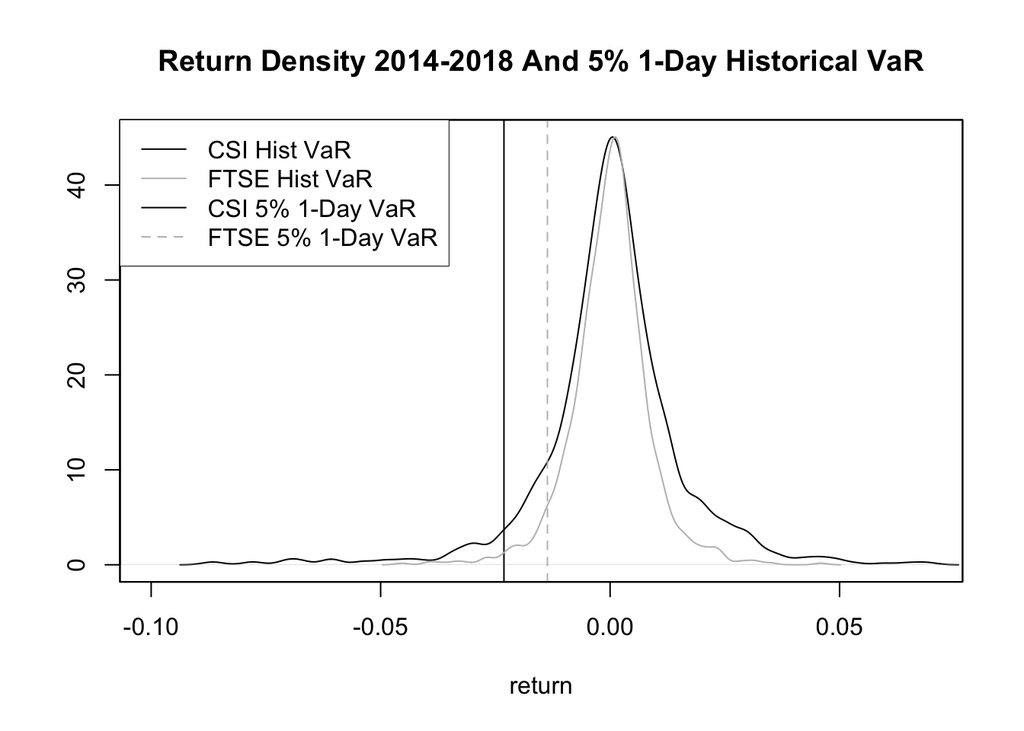

```r
ret.d.C = density(CSI300$ret)
ret.d.F = density(FTSE350$ret)
plot(ret.d.C,
     xlab='return',
     ylab="",
     type = 'l',
     xlim=c(-0.1,0.07),
     main='Return Density 2014-2018 And 5% 1-Day Historical VaR')

abline(v=-var.hist_C.q5/investment,col="black",lty=1)
abline(v=-var.hist_F.q5/investment,col="grey",lty=2)
par(new=T)
plot(ret.d.F,
     xlab='',
     ylab='',
     main='',
     yaxt='n',
     xaxt='n',
     xlim=c(-0.1,0.07),
     type='l', col='gray'
     )
legend("topleft",box.lwd=0.5,
       c("CSI Hist VaR",
         "FTSE Hist VaR",
         "CSI 5% 1-Day VaR",
         "FTSE 5% 1-Day VaR"),
       col=c("black","gray","black","gray"),
       lty=c(1,1,1,2))
```

### Gaussian ES

```r
es_C.q5 = investment * (mu_c+sigma_c*dnorm(qnorm(0.05))/0.05)
es_F.q5 = investment * (mu_f+sigma_f*dnorm(qnorm(0.05))/0.05)
print(paste0("ES_C.q5=",round(es_C.q5,2)))
```

```
## [1] "ES_C.q5=32775.6"
```

```r
print(paste0("ES_F.q5=",round(es_F.q5,2)))
```

```
## [1] "ES_F.q5=17801.4"
```

### Historical ES

```r
CSI300$pl = CSI300$ret * investment
FTSE350$pl = FTSE350$ret * investment
# generate an empty dummy variable firstly
CSI300$dummy.q5=NA
CSI300[which(CSI300$pl<=(-var.hist_C.q5)),]$dummy.q5=1
FTSE350 = FTSE350 %>% mutate(dummy.q5=ifelse(pl<=(-var.hist_F.q5),1,NA))
#  Compute Average of Losses in Excess of VaR
CSI300$es.q5 = -CSI300$dummy.q5 * CSI300$pl
FTSE350$es.q5 = -FTSE350$dummy.q5 * FTSE350$pl
es.hist_C.q5 = mean(CSI300$es.q5,na.rm=T)
es.hist_F.q5 = mean(FTSE350$es.q5,na.rm=T)

cat("CSI300 Historical ES 0.05 = ",round(es.hist_C.q5,2),"\n")
```

```
## CSI300 Historical ES 0.05 =  41230.71
```

```r
cat("FTSE350 Historical ES 0.05 = ",round(es.hist_F.q5,2),"\n")
```

```
## FTSE350 Historical ES 0.05 =  20577.26
```

2. If you invest the two indices with equal weights in the first day and do not reallocate later on, and the total investment is still 1 million dollar. Calculate the historical and Gaussian $VaR_{0.05}$ and the corresponding expeted shortfall for the portfolio. Compare the results with part a. What is your conclusion?

Step1: Calculate portfolio rets

```r
port=ind.g.price %>% group_by(gvkeyx) %>% arrange(date) %>% mutate(ret=price/lag(price,1)-1) %>% ungroup
port= port %>% filter(!is.na(ret)) %>% group_by(gvkeyx) %>%
        arrange(date) %>% mutate(cumret=cumprod(ret+1))%>% ungroup
port=port %>% group_by(date) %>% summarise(idx.p=mean(cumret)) %>% ungroup
port= port %>% arrange(date) %>% mutate(ret=idx.p/lag(idx.p,1)-1) %>% filter(!is.na(ret))
```

Step2: Calculate portfolio Gaussian VaR and Historical VaR

```r
# Gaussian VaR
mu_p=mean(port$ret)
sigma_p=sd(port$ret)
print(paste0("mu_p = ", mu_p))
```

```
## [1] "mu_p = 0.000186424676403098"
```

```r
print(paste0("sigma_p = ", sigma_p))
```

```
## [1] "sigma_p = 0.0107976114727058"
```

```r
var_P.q5=-(sigma_p * q5 + mu_p) * investment
print(paste0(" portfolio VaR(0.05) = ", round(var_P.q5,2)))
```

```
## [1] " portfolio VaR(0.05) = 17574.07"
```

```r
# Historical VaR
var.hist_P.q5 = -investment * quantile(port$ret, probs=0.05, type=3, na.rm=T)
print(paste0("portfolio VaR(0.05) = ", round(var.hist_P.q5,2)))
```

```
## [1] "portfolio VaR(0.05) = 16022.18"
```

```r
# Gaussian ES
es_P_q5 = investment * (mu_p + sigma_p*dnorm(qnorm(0.05))/0.05)
print(paste0("Gaussian ES(0.05)=",round(es_P_q5,2)))
```

```
## [1] "Gaussian ES(0.05)=22458.8"
```

```r
# Historical ES
port$pl = port$ret * investment
# generate an empty dummy variable firstly
port$dummy.q5=NA
port[which(port$pl<=(-var.hist_P.q5)),]$dummy.q5=1
#  Compute Average of Losses in Excess of VaR
port$es.q5 = -port$dummy.q5 * port$pl
es.hist_P.q5 = mean(port$es.q5,na.rm=T)

cat("portfolio Historical ES 0.05 = ",round(es.hist_P.q5,2))
```

```
## portfolio Historical ES 0.05 =  28473.19
```

make comparison

```r
var_CF=(1/2)*(var_C.q5+var_F.q5)
var.hist_CF=(1/2)*(var.hist_C.q5+var.hist_F.q5)
es_CF=(1/2)*(es_C.q5+es_F.q5)
es.hist_CF=(1/2)*(es.hist_C.q5+es.hist_F.q5)

G.VaR=c(var_CF, var_P.q5)
H.VaR=c(var.hist_CF, var.hist_P.q5)
G.ES=c(es_CF, es_P_q5)
H.ES=c(es.hist_CF, es.hist_P.q5)
df=data_frame(G.VaR, H.VaR, G.ES, H.ES)
rownames(df)=c('average of CSI300 & FTSE350', 'portfolio')
print(df)
```

```
## # A tibble: 2 x 4
##    G.VaR  H.VaR   G.ES   H.ES
## *  <dbl>  <dbl>  <dbl>  <dbl>
## 1 19810. 18392. 25288. 30904.
## 2 17574. 16022. 22459. 28473.
```

3. Calculate the drawdowns for the two indices and make a plot of that. When did the longest drawdown periods appear for the two indices? What are the maximum drawdowns respectively?

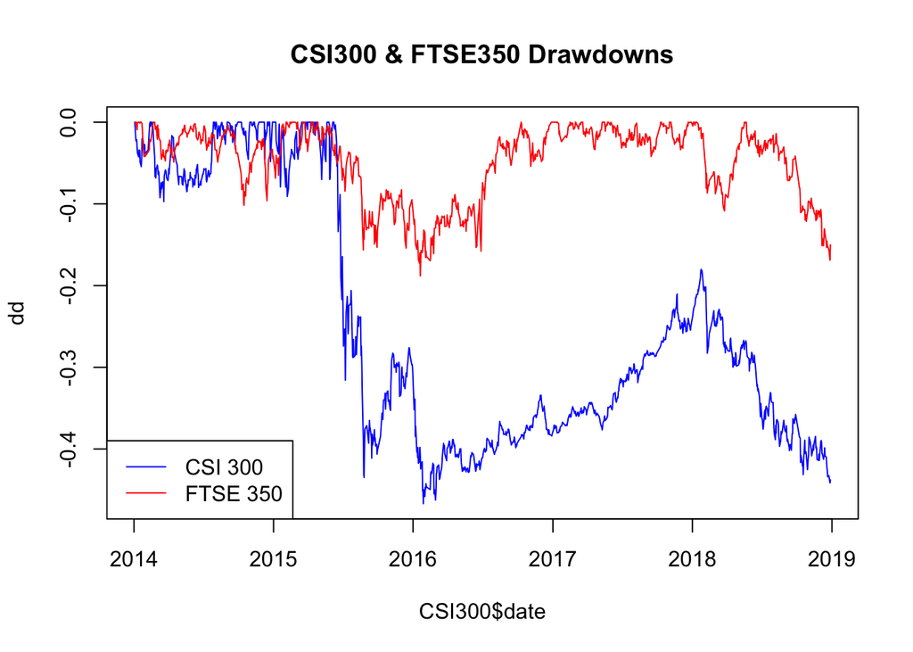

```r
CSI300 = CSI300 %>% mutate(dd=(price-cummax(price))/cummax(price))
FTSE350 = FTSE350 %>% mutate(dd=(price-cummax(price))/cummax(price))
plot(CSI300$dd~CSI300$date,type='l',ylab='dd',
     main='CSI300 & FTSE350 Drawdowns',
     col='blue')
lines(FTSE350$dd~FTSE350$date, type='l', col='red')
legend('bottomleft', c('CSI 300','FTSE 350'),
       lty=c(1,1),
       col=c("blue","red"))
```

```r
# calculate maximum drawdown
dd_C.max = max(-CSI300$dd)
dd_C.max
```

```
## [1] 0.4669605
```

```r
dd_F.max = max(-FTSE350$dd)
dd_F.max
```

```
## [1] 0.1881586
```

```r
# calculate longest period in drawdown
CSI300$dd = round(CSI300$dd,4)
CSI300 = CSI300 %>% mutate(dd.flag = ifelse(dd<0,1,0))
FTSE350$dd = round(FTSE350$dd,4)
FTSE350 = FTSE350 %>% mutate(dd.flag = ifelse(dd<0,1,0))

rles_C = rle(CSI300$dd.flag==1)
summary(rles_C$lengths[rles_C$values==T])
```

```
##    Min. 1st Qu.  Median    Mean 3rd Qu.    Max.
##    1.00    1.00    2.50   43.08   15.00  847.00
```

```r
cat('the longest period in drawdown of CSI 300 is', max(rles_C$lengths[rles_C$values==T]), 'days')
```

```
## the longest period in drawdown of CSI 300 is 847 days
```

```r
rles_F = rle(FTSE350$dd.flag==1)
summary(rles_F$lengths[rles_C$values==T])
```

```
##    Min. 1st Qu.  Median    Mean 3rd Qu.    Max.
##    1.00    1.00    7.00   36.19   24.50  344.00
```

```r
cat('the longest period in drawdown of FTSE350 is', max(rles_F$lengths[rles_F$values==T]), 'days')
```

```
## the longest period in drawdown of FTSE350 is 344 days
```

4. Calculate the drawdowns (including the longest drawdown period and the maximum drawdown) for the portfolio and make comparison with part c.

```r
port = port %>% mutate(dd=(idx.p-cummax(idx.p))/cummax(idx.p))
dd_P.max = max(-port$dd)
dd_P.max
```

```
## [1] 0.3602255
```

```r
port$dd = round(port$dd,4)
port = port %>% mutate(dd.flag = ifelse(dd<0,1,0))
rles_P = rle(port$dd.flag==1)
summary(rles_P$lengths[rles_P$values==T])
```

```
##    Min. 1st Qu.  Median    Mean 3rd Qu.    Max.
##    1.00    1.00    4.00   38.52    9.00  847.00
```

```r
cat('the longest period in drawdown of the portfolio is', max(rles_P$lengths[rles_P$values==T]), 'days')
```

```
## the longest period in drawdown of the portfolio is 847 days
```

make plot

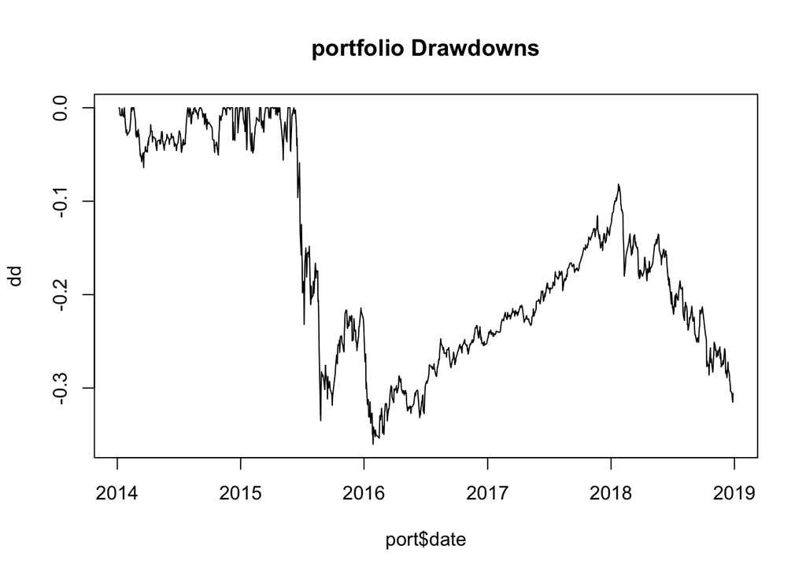

```r
plot(port$dd~port$date,type='l',ylab='dd',
     main='portfolio Drawdowns',
     col='black')
```

### Q3: Use the data obtained from Q2. Calculate the probability that returns of the two indices are both negative in one day, and then calculate the co-drawdown.

```r
df3 = merge(CSI300, FTSE350, all.x = T, all.y = T) %>%
        select(date, gvkeyx, dd)
codd = spread(df3, gvkeyx, dd)
colnames(codd)=c('date','dd_F','dd_C')
summary(codd)
```

```
##       date                 dd_F               dd_C
##  Min.   :2014-01-03   Min.   :-0.18820   Min.   :-0.4670
##  1st Qu.:2015-04-07   1st Qu.:-0.07640   1st Qu.:-0.3763
##  Median :2016-07-01   Median :-0.03080   Median :-0.2980
##  Mean   :2016-06-30   Mean   :-0.04758   Mean   :-0.2493
##  3rd Qu.:2017-09-22   3rd Qu.:-0.01360   3rd Qu.:-0.0679
##  Max.   :2018-12-28   Max.   : 0.00000   Max.   : 0.0000
```

```r
codd = codd %>%
  mutate(anydown = pmin(dd_C,dd_F)) %>%
  mutate(codown = pmax(dd_C,dd_F))
codd = codd %>% mutate(neg.signal=ifelse(codown<0,1,NA))
prob.neg = sum(codd$neg.signal, na.rm=T)/length(codd$date)
cat('the probability that rets of the two indices are both negative is ',prob.neg)
```

```
## the probability that rets of the two indices are both negative is  0.8962025
```

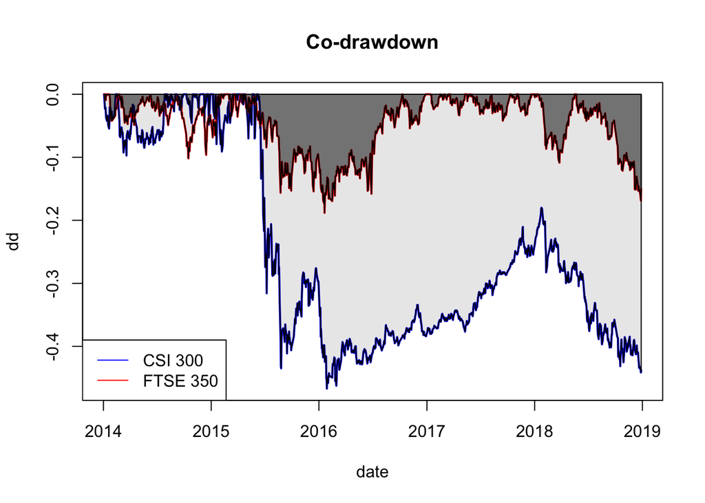

```r
# make plot
codd$zeroline=0
yrange=range(df3$dd)
plot(codd$dd_C~codd$date,
     type='l', lwd = 2, col = 'blue',
     xlab = 'date',ylab ='dd',ylim=yrange,
     main='Co-drawdown')

lines(codd$dd_F~codd$date,
      lwd = 2,
      col='red')
legend('bottomleft', c('CSI 300','FTSE 350'),
       lty=c(1,1),
       col=c("blue","red"))

with(codd,
     polygon(c(date,rev(date)),
             c(zeroline,rev(anydown)),
             col=rgb(0, 0, 0, 0.1)))

with(codd,
     polygon(c(date,rev(date)),
             c(zeroline,rev(codown)),
             col=rgb(0, 0, 0, 0.5)))
```

calculate probability of co-drawdown

```r
codd.p = sum(codd$codown)/sum(codd$anydown)
codd.p
```

```
## [1] 0.1732693
```